# Medidas de desempeño sobre predicción

Luis Fernando Apáez Álvarez

24/11/2021

Comenzamos por cargar los datos

```r
library(latex2exp)
Datos = read.csv("ejemplo4.csv")
```

Luego, para usar funciones del paquete `boot` se ajusta usando la función `glm` en vez de utilizar la función para el ajuste del modelo `lm`, donde el paquete `boot` tiene funciones que nos permiten realizar la variación cruzada. Por default `glm` coincide con el caso normal de la `lm` pero tiene más argumentos para funcionar con modelos lineales generalizados.

```r
library(boot)
fitglm=glm(y~x, data=Datos)
summary(fitglm)
```

```
##
## Call:
## glm(formula = y ~ x, data = Datos)
##
## Deviance Residuals:
##     Min       1Q   Median       3Q      Max
## -5.7847  -2.8954  -0.9503   2.3287   7.8916
##
## Coefficients:
##             Estimate Std. Error t value Pr(>|t|)
## (Intercept)  -9.9928     0.8039  -12.43   <2e-16 ***
## x             5.5151     0.1296   42.57   <2e-16 ***
## ---
## Signif. codes:  0 '***' 0.001 '**' 0.01 '*' 0.05 '.' 0.1 ' ' 1
##
## (Dispersion parameter for gaussian family taken to be 13.84727)
##
##     Null deviance: 26451  on 99  degrees of freedom
## Residual deviance:  1357  on 98  degrees of freedom
## AIC: 550.58
##
## Number of Fisher Scoring iterations: 2
```

en el cual podemos notar la similitud que hay entre la información que nos arrojaba el `lm` y lo que nos arroja el `glm`, así como las diferencias pues en este caso no se muestra la información de la prueba $F$, el valor de $R^{2}$, etcétera.

Posteriormente, recordemos que en estos datos no hay linealidad por lo que procediamos a transformar

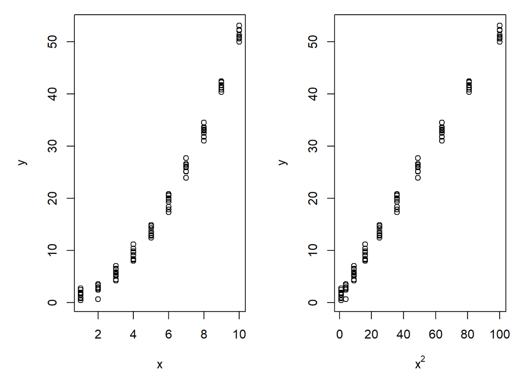

```r
# Transformamos los datos
Datos$Xprima=Datos$x^2

# Graficamos
par(mfrow=c(1,2))
par(mar=c(4, 5, 1, 1))

# Datos no transformados
plot(Datos$x, Datos$y, xlab = TeX("$x$"), ylab=TeX("$y$") )

# Datos transformados
plot(Datos$Xprima, Datos$y, xlab = TeX("$x^2$"), ylab=TeX("$y$") )
```

y volvemos a realizar el ajuste del modelo usando `glm`

```r
fit2glm=glm(y~Xprima, data=Datos)
summary(fit2glm)
```

```
##
## Call:
## glm(formula = y ~ Xprima, data = Datos)
##
## Deviance Residuals:
##      Min        1Q    Median        3Q       Max
## -2.36940  -0.59665  -0.02778   0.58044   2.09823
##
## Coefficients:
##             Estimate Std. Error t value Pr(>|t|)
## (Intercept) 1.056729   0.142366   7.423 4.23e-11 ***
## Xprima      0.500875   0.002829 177.078  < 2e-16 ***
## ---
## Signif. codes:  0 '***' 0.001 '**' 0.01 '*' 0.05 '.' 0.1 ' ' 1
##
## (Dispersion parameter for gaussian family taken to be 0.8409146)
##
##     Null deviance: 26450.68  on 99  degrees of freedom
## Residual deviance:    82.41  on 98  degrees of freedom
## AIC: 270.44
##
## Number of Fisher Scoring iterations: 2
```

Así, con los modelos obtenidos en `fitglm` y `fit2glm` efectuaremos la comparación.

### Método de validación cruzada

```r
library(caret)
# colocamos una semilla puesto que realizaremos particiones aleatorias
set.seed(1234)
```

La función `createFolds()` del paquete `caret` ayuda a obtener la muestra en cada una de las $K$ divisiones.

```r
# Agregamos una nueva columna al dataframe con puros unos y la convertimos
# a una variable de tipo factor que nos servirá para la función createFolds
# para indicar cuántos elementos tenemos
Datos$unos=1
Datos$unos=factor(Datos$unos)

# Hacemos las diviones aleatorias en 10 particiones
Folds=createFolds(Datos$unos, k = 10, list = FALSE)
Folds
```

```
##   [1]  8 10  2  9  5  8  6  4  6 10 10  9  8  4  6  2  3  4  1 10  2  7  6  6  7
##  [26]  1  8  3  1  2  2  3  2  4  9  9  1  6  7  9  1  5  7  8  6  7  8  1 10  6
##  [51]  8  5  2  4  3 10 10  5  5  6  9  5  3  3 10  7  2  7  1  8  7  2  9  4  1
##  [76]  3  5  5  7  6  5  3  4  3  9  8  7  8  4  5  4  3  4  1  9  1  9  2 10 10
```

donde podemos ver 10 datos asignados a la partición 1, 10 datos a la partición 2, etcétera. Lo anterior puede verse en

```r
table(Folds)
```

```
## Folds
##  1  2  3  4  5  6  7  8  9 10
## 10 10 10 10 10 10 10 10 10 10
```

Una vez obtenido lo anterior, realizaremos un bucle `for` para ir probando los conjuntos de datos de las particiones como el conjunto para el *test*. Comenzamos definiendo las matrices

```r
SE1=matrix(0, 10,1)
SE2=matrix(0, 10,1)
```

en las que almacenaremos la suma de los errores al cuadrado correspodientes al modelo 1 (`fitglm`) y 2 (`fit2glm`). Analicemos primero una iteración antes de correr el `for` completo. Consideraremos $kj=1$.

1. ``Datos.train=Datos[(Folds==kj)==FALSE,]```: realizamos el filtro de nuestros datos para aquellos que no tengan asignados el valor de 1. Éstos serán nuestros datos tomados para “entrenar” el modelo.
2. `Datos.test=Datos[Folds==kj,]`: realizamos el filtro de nuestros datos para la partición 1, es decir, seleccionamos sólo aquellos datos que tengan asignados el valor de uno. Éstos serán nuestros datos para probar el modelo.
3. `fitkj1=lm(y~x, data=Datos.train)`: ajustamos el modelos sólo para los datos del entrenamiento.
4. `predkj1=predict(fitkj1, Datos.test)`: utilizando el objeto `lm` obtenido en el punto anterior realizamos la predicción correspondiente con los datos del *test*.
5. `SE1[kj,1]=sum((Datos.test$y-predkj1)^2)`: finalmente guardamos en la matriz `SE1` la suma de los errores al cuadrado, donde `Datos.test$y-predkj1` representa la diferencia entre el valor “real” de $y$ en el dataframe `Datos.test` con el valor predecido por `predkj1`

Repetimos lo mismo para el segundo modelo

```
  # En este caso usamos los valores de la x transformada
  fitkj2=lm(y~Xprima, data=Datos.train)

  predkj2=predict(fitkj2, Datos.test)
  SE2[kj,1]=sum((Datos.test$y-predkj2)^2)
```

Por consiguiente

```r
for(kj in 1:10){
  Datos.train=Datos[(Folds==kj)==FALSE,]
  Datos.test=Datos[Folds==kj,]
  fitkj1=lm(y~x, data=Datos.train)
  predkj1=predict(fitkj1, Datos.test)
  SE1[kj,1]=sum((Datos.test$y-predkj1)^2)

  fitkj2=lm(y~Xprima, data=Datos.train)
  predkj2=predict(fitkj2, Datos.test)
  SE2[kj,1]=sum((Datos.test$y-predkj2)^2)
}
```

y vemos las sumas de los errores al cuadrao calculados para cada partición

```r
SE1
```

```
##            [,1]
##  [1,] 147.23557
##  [2,] 134.96619
##  [3,]  78.89767
##  [4,] 102.69749
##  [5,] 133.67675
##  [6,] 184.89389
##  [7,] 116.90607
##  [8,] 172.39307
##  [9,] 134.02468
## [10,] 213.01157
```

```r
SE2
```

```
##            [,1]
##  [1,]  8.939381
##  [2,] 16.977388
##  [3,]  3.288027
##  [4,] 11.122032
##  [5,]  3.698293
##  [6,]  4.627293
##  [7,]  5.718196
##  [8,] 13.257321
##  [9,]  9.247512
## [10,] 11.176527
```

Procedemos después a calcular el promedio, donde sumaremos los valores respectivos de la matriz y lo dividiremos entre 100. Recordemos que cada entrada de la matriz al ser promediada debía ser dividida entre 10, pues cada partición tenía 10 datos, y como queremos el promedio de la suma de los errores al cuadrado respectivas de cada partición, entonces dividiremos entre $10\times 10$ porque hay $k=10$ particiones. Luego

```r
(MSEtest1=sum(SE1)/length(Folds))
```

```
## [1] 14.18703
```

```r
(MSEtest2=sum(SE2)/length(Folds))
```

```
## [1] 0.8805197
```

Notemos que lo hecho anteriormente se debe hacer $B$ veces, pues antes sólo realizamos una forma de particionar los datos y en realidad debe probarse efectuando más de una forma de particionar, es decir, lo anterior se debe realizar $B$ veces y se promedia. Existen dos opciones en `R` que ya hacen ese proceso.

Comenzamos utilizando la función `cv.glm` de la librería `boot`

```r
# Valores necesarios
B=200
K=10

# 10-CV. Validación cruzada
library(boot)
set.seed(123)

# repeticiones
cvLRfit1=rep(NA,B)

for (i in 1:B){
  cvLRfit1[i]=cv.glm(Datos, fitglm, K=K)$delta[1]
}
(mean(cvLRfit1))
```

```
## [1] 14.31204
```

```r
set.seed(123)
cvLRfit2=rep(NA,B)
for (i in 1:B){
  cvLRfit2[i]=cv.glm(Datos, fit2glm, K=K)$delta[1]
}
(mean(cvLRfit2))
```

```
## [1] 0.8571143
```

La otra alternativa es utilizar la función `repCV` de la librería `cvTools`

```r
library(cvTools)
set.seed(123)

# número de particiones y número de repeticiones
folds <- cvFolds(nrow(Datos), K = K, R = B)

# Modelo 1
fit=lm(y~x, data=Datos)
repCV(fit, cost = mspe, folds = folds)
```

```
## 10-fold CV results:
##       CV
## 14.34317
```

```r
# Modelo 2
fit2=lm(y~Xprima, data=Datos)
repCV(fit2, cost = mspe, folds = folds)
```

```
## 10-fold CV results:
##        CV
## 0.8577174
```